# Tree Based Models

Decision Trees & Random Forest  
Dr. Jomana Bashatah  
Slides adapted from Casten Lange

# Decision Trees

## Introduction

- Decision Trees can be used for
  - Classification
  - Regression
- Decision Trees can be used as standalone algorithms (this is what we do here)
- Decision Trees can be used as components for other models such as:
  - Random Forest Models
  - Boosted Tree Models

## Introducing the Idea of Decision Trees with the Titanic Dataset

```r
library(rio); library(tidymodels); library(janitor)
library(kableExtra)
DataTitanic=import("Data/Titanic.csv") |>
            clean_names("upper_camel") |>
             select(Survived, Gender, Class=Pclass, Age, Fare=FareInPounds) |>
             mutate(Survived=as.factor(Survived))

set.seed(777)
Split7525=initial_split(DataTitanic, strata = Survived)

DataTrain=training(Split7525)
DataTest=testing(Split7525)
```

| Survived | Gender | Class | Age | Fare |
| --- | --- | --- | --- | --- |
| 0 | male | 3 | 35 | 8.0500 |
| 0 | male | 1 | 54 | 51.8625 |
| 0 | male | 3 | 2 | 21.0750 |
| 0 | male | 3 | 20 | 8.0500 |
| 0 | male | 3 | 39 | 31.2750 |

## Generating a Decision Tree with `tidymodels`

Note, `rpart` package needs to be installed. `tidymodels` loads the `rpart` package automatically. Therefore `library(rpart)` is not needed.

```r
ModelDesignDecTree=decision_tree(tree_depth=3) |>
                    set_engine("rpart") |>
                    set_mode("classification")

RecipeTitanic=recipe(Survived~., data=DataTrain)

set.seed(777)
WfModelTitanic=workflow() |>
               add_model(ModelDesignDecTree) |>
               add_recipe(RecipeTitanic) |>
               fit(DataTrain)
print(WfModelTitanic)
```

```
══ Workflow [trained] ══════════════════════════════════════════════════════════
Preprocessor: Recipe
Model: decision_tree()

── Preprocessor ────────────────────────────────────────────────────────────────
0 Recipe Steps

── Model ───────────────────────────────────────────────────────────────────────
n= 664

node), split, n, loss, yval, (yprob)
      * denotes terminal node

 1) root 664 256 0 (0.61445783 0.38554217)
   2) Gender=male 428  84 0 (0.80373832 0.19626168)
     4) Age>=13 400  68 0 (0.83000000 0.17000000) *
     5) Age< 13 28  12 1 (0.42857143 0.57142857)
      10) Class>=2.5 20   8 0 (0.60000000 0.40000000) *
      11) Class< 2.5 8   0 1 (0.00000000 1.00000000) *
   3) Gender=female 236  64 1 (0.27118644 0.72881356)
     6) Class>=2.5 114  56 0 (0.50877193 0.49122807)
      12) Fare>=23.35 22   1 0 (0.95454545 0.04545455) *
      13) Fare< 23.35 92  37 1 (0.40217391 0.59782609) *
     7) Class< 2.5 122   6 1 (0.04918033 0.95081967) *
```

## Displaying the Decision Tree with `rpart.plot`

Note, `rpart.plot` package needs to be installed and loaded with `library(rpart.plot)`.

```r
library(rpart.plot)
rpart.plot(extract_fit_engine(WfModelTitanic),roundint=FALSE)
```

[output not shown]

## Nodes in the Decision Tree (ignore decision rules for now)

- Nodes are like containers holding all or some of the training data
  - *root* node holds all training observations.
  - moving down the tree *parent nodes* get split into *child nodes*
- `RPart` nodes show three types of information.»

## Nodes in the Decision Tree — The Optimizer Created Decision Rules

Let us follow the last observation in `DataTrain`

|  | Survived | Gender | Class | Age | Fare |
| --- | --- | --- | --- | --- | --- |
| 664 | 1 | male | 1 | 26 | 30 |

## Nodes in the Decision Tree — Interpreting Terminal Nodes

## Nodes in the Decision Tree — Stylized Facts

1. Adult male passengers, regardless of the class and fare, had only a survival rate of 17%.
2. Female passengers, regardless of age and not considering the class or the fare, had a survival chance of 73%.
3. Considering the class female passengers traveled in (regardless of age), the survival rate was 95% for First or Second Class.

## Nodes in the Decision Tree — Not all Decision Rules Make Sense

For example:

- Females traveling in Third Class have a survival rate of 49% (**this makes sense**)
- Next split **does not make much sense:**
  - Fare greater or equal to 23 British Pounds survival rate only 5%.
  - In contrast, lower fare had a survival rate of 60%.»

## Predicting Testing Data with a Decision Tree

Predicting Survival (9-year Old Boy in Third Class)

| Survived | Gender | Class | Age | Fare |
| --- | --- | --- | --- | --- |
| 1 | male | 3 | 9 | 15.9 |

Prediction: `Not Survived`

Observation is a `false positive` (0=:positive class)»

## Predicting all Testing Data with a Decision Tree — Prediction

```r
DataTestWithPred=augment(WfModelTitanic, new_data =  DataTest)
head(DataTestWithPred)
```

```
# A tibble: 6 × 8
  .pred_class .pred_0 .pred_1 Survived Gender Class   Age  Fare
  <fct>         <dbl>   <dbl> <fct>    <chr>  <int> <dbl> <dbl>
1 0            0.83     0.17  0        male       3    22  7.25
2 1            0.0492   0.951 1        female     1    35 53.1
3 0            0.83     0.17  0        male       3    27  8.46
4 1            0.402    0.598 1        female     3    27 11.1
5 1            0.402    0.598 0        female     3    31 18
6 0            0.83     0.17  0        male       2    35 26
```

## Predicting all Testing Data with a Decision Tree — Metrics

```r
DataTestWithPred=augment(WfModelTitanic, new_data =  DataTest)
```

```r
conf_mat(DataTestWithPred, truth = Survived, estimate = .pred_class)
```

```
          Truth
Prediction   0   1
         0 123  23
         1  14  63
```

```r
metricSetTitanic=metric_set(accuracy, sensitivity, specificity)
metricSetTitanic(DataTestWithPred, truth = Survived, estimate = .pred_class)
```

```
# A tibble: 3 × 3
  .metric     .estimator .estimate
  <chr>       <chr>          <dbl>
1 accuracy    binary         0.834
2 sensitivity binary         0.898
3 specificity binary         0.733
```

## How are the Decision Rules Determined?

The short answer: **by the *Optimizer*.**

- Decision rules are determined from the top down to the bottom.
- Regardless of decision rule on next level.
  - No turning back reversing decision rule on higher level.
  - *greedy algorithm*
- Decision rules consists of two components:
  1. the **splitting variable**,
  2. the **splitting value** (e.g., `Age` for splitting (here: `Age>=13` for `yes`)

*Optimizer* compares all *splitting variables* and all possible *splitting values* to find **best decision rule**.»

## Criteria to Quantify Quality of Decision Rules

**How can we determine if a decision rule is good?**

Common criteria for categorical outcomes:

- *Information Gain*
- *Chi-Square*
- **Gini Impurity** used by `RPart` »

## How are the Decision Rules Determined? — Gini Impurity Criterium

**Gini Impurity** is calculated for an individual node and estimates ” (…) the probability that two entities taken at random from the dataset of interest (with replacement) represent (…) different types.”  
(Wikipedia contributors. 2022. “Diversity Index — Wikipedia, the Free Encyclopedia.”)

## Criteria to Assess Decision Rules — Gini Impurity

$$\begin{aligned}
G^{Imp}&= 1- \overbrace{(P_{Surv.}^2 +
\underbrace{P_{Not Surv.}^2}_{(1-P_{Surv.})^2})}^{\text{Prob. for 2 identical outcomes}}
\end{aligned}$$

$P_{Surv.}:=$ Proportion Surv.  
and  
$P_{Not Surv.}:=$ Proportion Not Surv.

## Criteria to Assess Decision Rules — Gini Impurity

$$\begin{aligned}
G^{Imp}&= 1- \left (P_{Surv.}^2 + (1-P_{Surv.})^2\right ) \\
G^{Imp}&= 1- P_{Surv.}^2 - 1+2P_{Surv.}-P_{Surv.}^2 \\
G^{Imp}&= 2P_{Surv.}-2P_{Surv.}^2 \\
G^{Imp}&= 2 P_{Surv.} (1-P_{Surv.})
\end{aligned}$$

## Quantifying Quality of Decision Rules — Gini Impurity

$$G^{Imp} = 2 P_{Surv.} (1-P_{Surv.})$$
**Purest Possible Node:**

- Only *Survived* observations: $P_{Surv.}=1$ and $(1-P_{Surv.})=0$
- *or*
- only *Not Survived* observations: $P_{Surv.}=0$ and $(1-P_{Surv.})=1$
- **In any case:** $G^{Imp}=0$  
  (probability of drawing two different outcomes = 0)

## Quantifying Quality of Decision Rules — Gini Impurity

$$G^{Imp} = 2 P_{Surv.} (1-P_{Surv.})$$

**Impurest Possible Node:**

**Probability of drawing two different outcomes = 0.5**

## Determining Impurity for Root’s Parent and Child Nodes

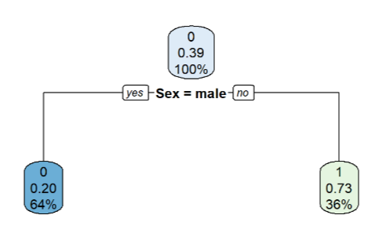

$$\begin{aligned}
G^{Imp}&= 2 P_{Surv.} (1-P_{Surv.}) \\
\\
G^{Imp}_{root}&= 2 \cdot 0.39 \cdot 0.61 = 0.48\\
\\
G^{Imp}_{YesChild}&= 2 \cdot 0.20 \cdot 0.80 = 0.32\\
G^{Imp}_{NoChild}&= 2 \cdot 0.73 \cdot 0.27 = 0.39\\
\\
G^{Imp}_{AvgChild}&= 0.64 \cdot 0.32 + 0.36 \cdot 0.39\\
&= 0.35
\end{aligned}$$

## Real World Data with a Decision Tree

Predicting vaccination rates in the U.S. based on data from September 2021:

- Outcome variable: Percentage of fully vaccinated (two shots) people ($PercVacFull$).
- Data from 2,630 continental U.S. counties.»

## Real World Data with a Decision Tree — Predictor Variables

- Race/Ethnicity:
  - Counties’ proportion African Americans ($PercBlack$),
  - Counties’ proportion Asian Americans ($PercAsian$), and
  - Counties’ proportion Hispanics ($PercHisp$)
- Political Affiliation (Presidential election 2020):
  - Counties’ proportion Republican votes ($PercRep$)
- Age Groups in Counties:
  - Counties’ proportion young adults (20-25 years); $PercYoung25$
  - Counties’ proportion older adults (65 years and older); $PercOld65$
- Income related:
  - Proportion of households receiving food stamps ($PercFoodSt$)»

## Loading the Data and Assigning Training and Testing Data

```r
DataVax=import("Data/DataVax.rds") |>
        select(County, State, PercVacFull, PercRep,
              PercAsian, PercBlack, PercHisp,
              PercYoung25, PercOld65, PercFoodSt)

set.seed(2021)
Split85=DataVax |> initial_split(prop = 0.85,
                                 strata = PercVacFull)

DataTrain=training(Split85) |> select(-County, -State)
DataTest=testing(Split85) |> select(-County, -State)
```

| PercVacFull | PercRep | PercAsian | PercBlack | PercHisp | PercYoung25 | PercOld65 | PercFoodSt |
| --- | --- | --- | --- | --- | --- | --- | --- |
| 0.416 | 0.4911710 | 0.0048 | 0.4744 | 0.0436 | 0.0734645 | 0.2332464 | 0.2637166 |
| 0.315 | 0.7063935 | 0.0112 | 0.3956 | 0.0238 | 0.0646534 | 0.2595095 | 0.1517111 |
| 0.318 | 0.8319460 | 0.0025 | 0.0460 | 0.0159 | 0.0525455 | 0.2786219 | 0.1626076 |
| 0.319 | 0.8402859 | 0.0002 | 0.0275 | 0.0246 | 0.0594866 | 0.2486424 | 0.1378972 |
| 0.394 | 0.8813559 | 0.0038 | 0.1339 | 0.0169 | 0.0603480 | 0.2756264 | 0.1429030 |
| 0.366 | 0.8343685 | 0.0028 | 0.3198 | 0.0233 | 0.0662870 | 0.2335378 | 0.1457801 |

## Creating Model Design, Recipe, and Fitted Workflow

```r
ModelDesignDecTree=decision_tree(tree_depth=3) |>
                    set_engine("rpart") |>
                    set_mode("regression")

RecipeVax=recipe(PercVacFull~., data=DataTrain)

WfModelVax=workflow() |>
               add_model(ModelDesignDecTree) |>
               add_recipe(RecipeVax) |>
               fit(DataTrain)
print(WfModelVax)
```

```
══ Workflow [trained] ══════════════════════════════════════════════════════════
Preprocessor: Recipe
Model: decision_tree()

── Preprocessor ────────────────────────────────────────────────────────────────
0 Recipe Steps

── Model ───────────────────────────────────────────────────────────────────────
n= 2233

node), split, n, deviance, yval
      * denotes terminal node

 1) root 2233 46.785150 0.5070156
   2) PercRep>=0.6838562 1135 14.122790 0.4401712
     4) PercRep>=0.7865135 523  5.637899 0.4108713 *
     5) PercRep< 0.7865135 612  7.652212 0.4652102
      10) PercBlack>=0.1029 99  1.834829 0.3832459 *
      11) PercBlack< 0.1029 513  5.023933 0.4810279 *
   3) PercRep< 0.6838562 1098 22.348720 0.5761124
     6) PercBlack>=0.20175 247  5.741888 0.4594514
      12) PercRep>=0.4169676 162  3.273037 0.4232727 *
      13) PercRep< 0.4169676 85  1.852682 0.5284038 *
     7) PercBlack< 0.20175 851 12.269520 0.6099729
      14) PercRep>=0.4900255 588  5.953630 0.5777697 *
      15) PercRep< 0.4900255 263  4.342780 0.6819711 *
```

## Decision Tree for the Vacciantion Model

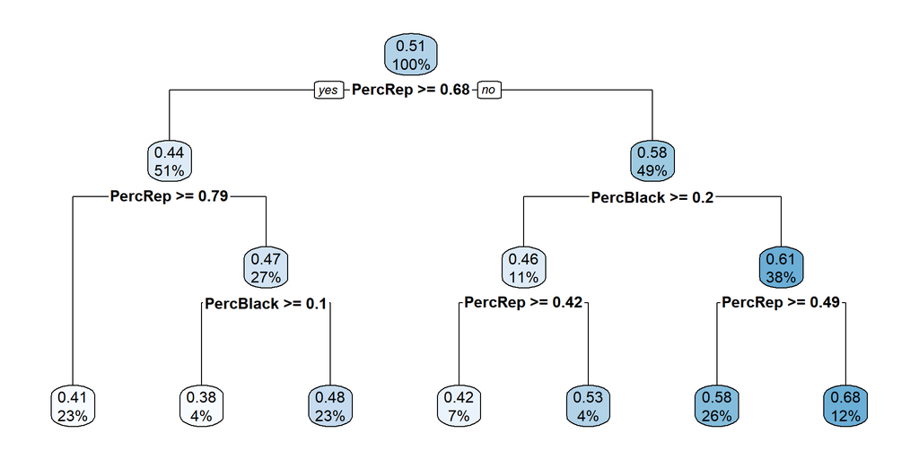

```r
rpart.plot(extract_fit_engine(WfModelVax),roundint=FALSE)
```

What is difference compared to a classification model?

- Terminal node estimates now continous variable.
- Variance instead of Gini Impurity

## Variance Reduction Explained

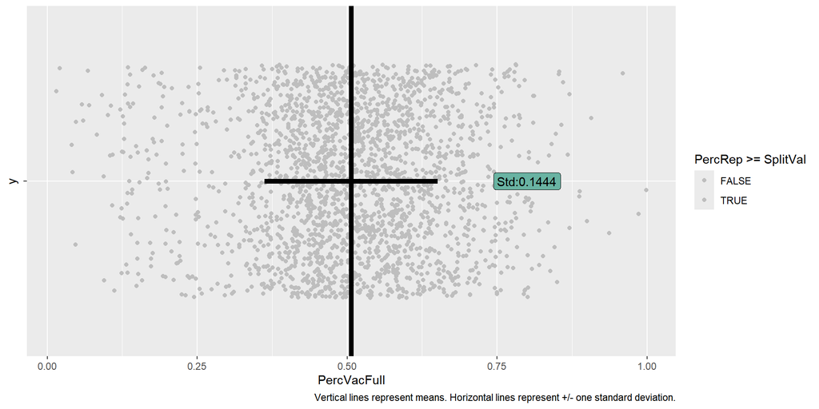

## Variance Reduction Explained (PercRep<0.68)

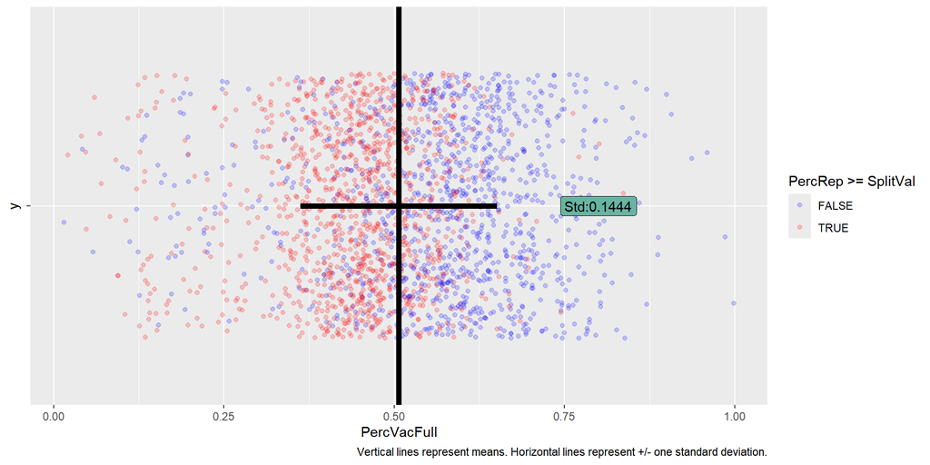

## Variance Reduction Explained (PercRep<0.68)

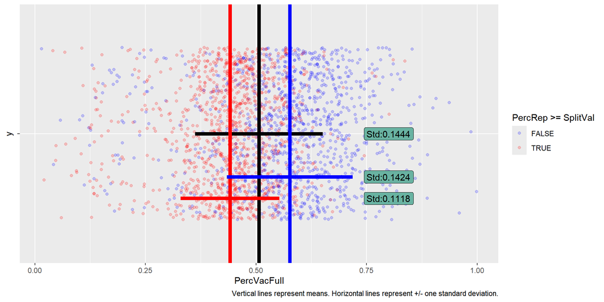

## Variance Reduction Explained (PercRep<0.68)

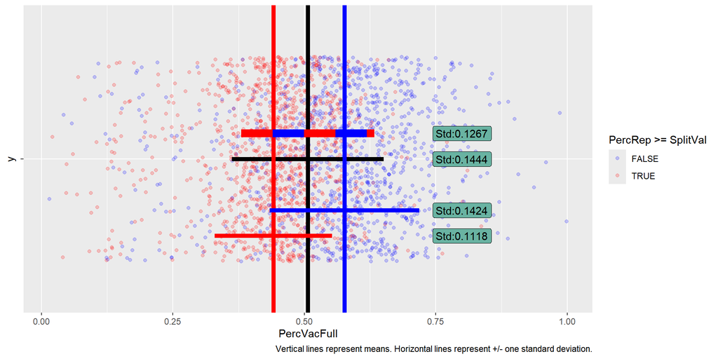

## Variance Reduction Explained

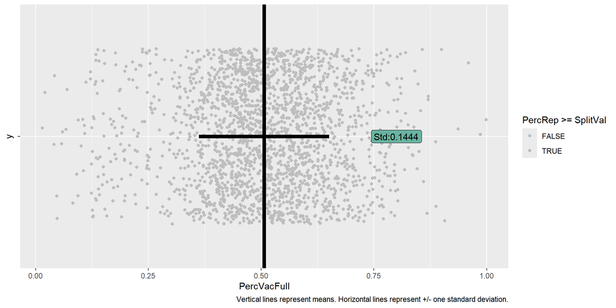

## Variance Reduction Explained (PercRep<0.5)

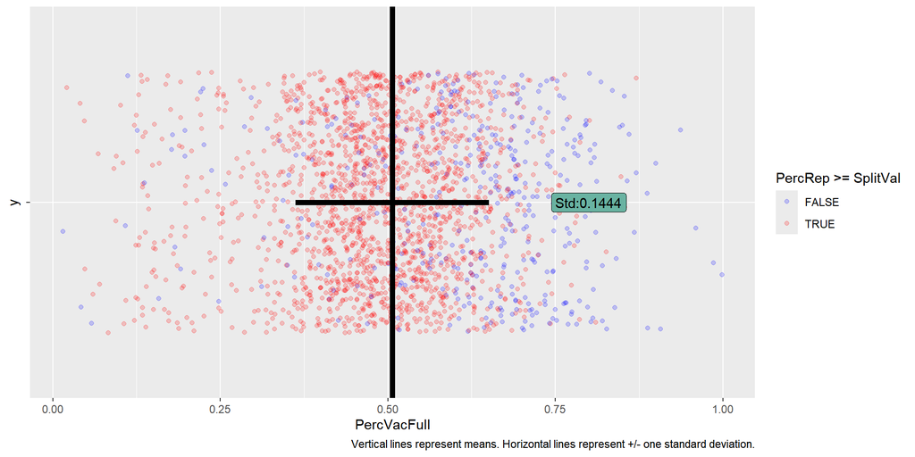

## Variance Reduction Explained (PercRep<0.5)

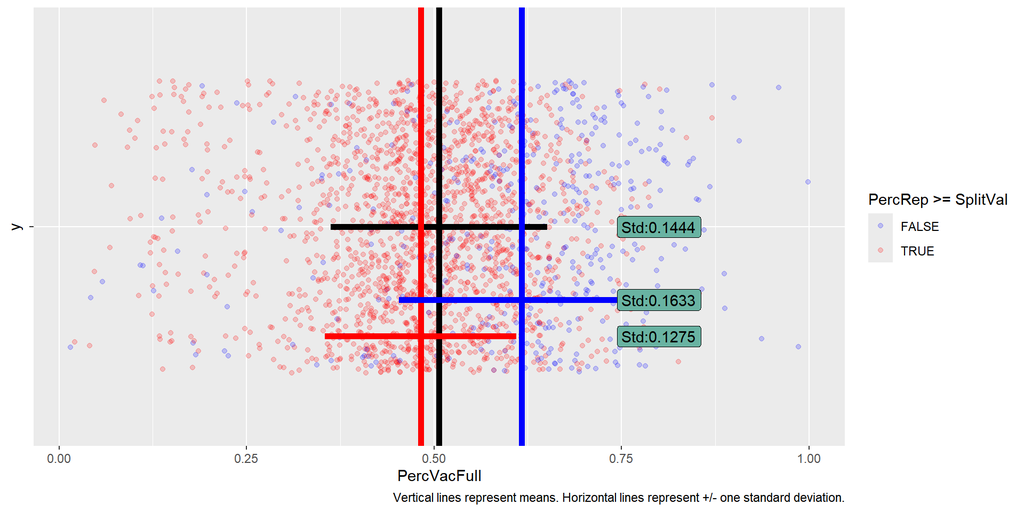

## Variance Reduction Explained (PercRep<0.5)

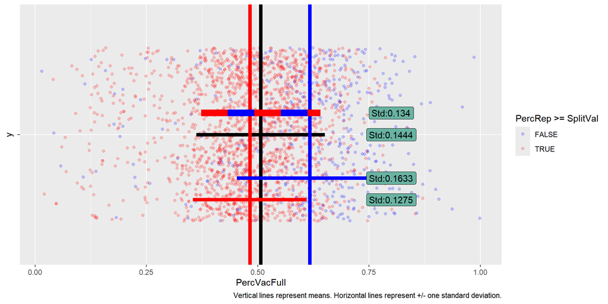

## Metrics for the Decision Tree Vaccination Model

```r
DataTestWithPred=augment(WfModelVax, new_data=DataTest)
metrics(DataTestWithPred, truth=PercVacFull, estimate=.pred)
```

```
# A tibble: 3 × 3
  .metric .estimator .estimate
  <chr>   <chr>          <dbl>
1 rmse    standard      0.128
2 rsq     standard      0.307
3 mae     standard      0.0940
```

## Instability of Decision Trees

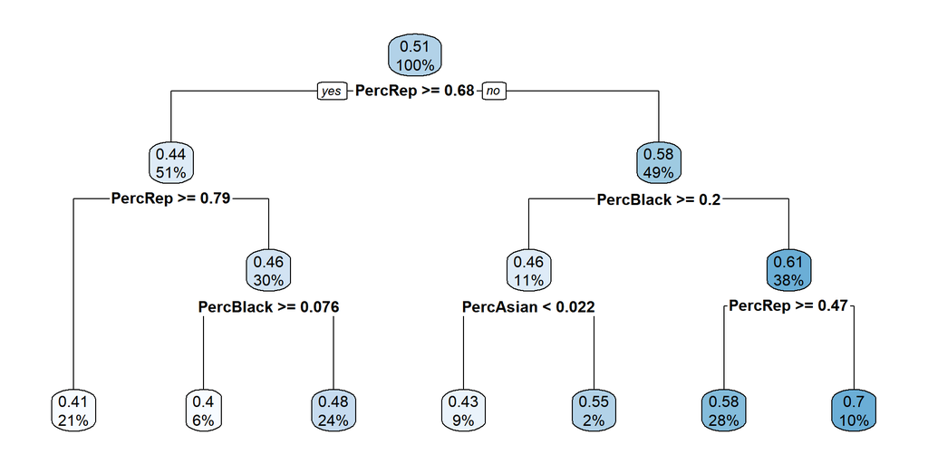

```r
set.seed(777)
Split85=DataVax |> initial_split(prop = 0.85,
                                 strata = PercVacFull)

DataTrain=training(Split85) |> select(-County, -State)
DataTest=testing(Split85) |> select(-County, -State)


ModelDesignDecTree=decision_tree(tree_depth=3) |>
                    set_engine("rpart") |>
                    set_mode("regression")

RecipeVax=recipe(PercVacFull~., data=DataTrain)

WfModelVax=workflow() |>
               add_model(ModelDesignDecTree) |>
               add_recipe(RecipeVax) |>
               fit(DataTrain)
rpart.plot(extract_fit_engine(WfModelVax),roundint=FALSE)
```

## Metrics for the (slightly) Changed Decision Tree Vaccination Model

```r
DataTestWithPred=augment(WfModelVax, new_data=DataTest)
metrics(DataTestWithPred, truth=PercVacFull, estimate=.pred)
```

```
# A tibble: 3 × 3
  .metric .estimator .estimate
  <chr>   <chr>          <dbl>
1 rmse    standard      0.118
2 rsq     standard      0.343
3 mae     standard      0.0858
```

## When and When Not to Use Decision Trees

- As a standalone model *Decision Trees* should not be used for predictions. Here is why:
  - *Decision Trees* respond very sensitively to a change in hyperparameters such as the tree depth. Therefore, the tree’s structure can change, which may also change the predictions.
  - *Decision Trees* respond very sensitively to a change in the training data. Therefore, when choosing different training data (e.g., by changing the `set.seed()`), the tree’s structure can change, which may also change the predictions.
- Decision Trees have an educational value because the graphical representation provides an easy way to see which variables influenced the predictions.
- Using Decision Trees as components of more advanced models like *Random Forest* and *Boosted Trees* often leads to excellent predictive results.

# Random Forest

## Introduction

- *Random Forest* can be used for
  - Classification
  - Regression
- A *Random Forest* model is an ensamble model consisting of many (hundreds or thousands) of slightly different *Decision Trees*.
- The majority predictions (majority vote) from all *Decision Trees* becomes the prediction of the *Random Forest* for classification»
- The average predictions from all *Decision Trees* becomes the prediction of the *Random Forest* for regression»

## The Idea Behind Random Forest

The idea that a combination of weak predictors can lead to a strong prediction is analogous to the wisdom of crowds phenomenon described in Galton 1907:

*Visitors at a stock and poultry exhibition in England submitted guesses about the weight of an ox. Although most of the visitors were off with their predictions, surprisingly the mean of all predictions was very close to the real weight of the ox.*»

## How to ensure that Decision Trees are (slightly) Different

- **Random Subspace Method:** Each decision tree uses only a random selection of the predictors.
  - As a rule of thumb: If we have $m$ predictors, each decision tree uses only $\sqrt(M)$ predictors (rounded down if needed).
  - In the case here, where we have $7$ predictors, each decision tree uses only $2$ randomly chosen predictors ($\sqrt(7)=2.65$ rounded down to $2$)
- **Bagging:** Each decision tree is presented with slightly different training data: We draw from the original training data with replacement to step-wise generate a new training dataset (**Bootstrapping**).
  - The new training dataset has the same size as the original dataset.
  - Generate a bootstrap dataset for every decision tree.

## Example for Bagging with Bootstapping

Creating 5 Bootstrap Training Datasets `DataTrain1`, `DataTrain2`, `DataTrain3`, `DataTrain4`, `DataTrain5` from original dataset `DataTrain`.

**Original Training Data:**

```r
DataTrain= tibble(ID=seq(1:7),
                  name=c("Adam","Berta","Carlos","Dora","Ernst","Fiola","Gert"),
                  gender=c("male","female","male","female","male","female","male"),
                  Age=c(22,54,32,21,32,87,18),
                  Weight=c(145,180,167,197,221,146,230))
kbl(DataTrain)
```

| ID | name | gender | Age | Weight |
| --- | --- | --- | --- | --- |
| 1 | Adam | male | 22 | 145 |
| 2 | Berta | female | 54 | 180 |
| 3 | Carlos | male | 32 | 167 |
| 4 | Dora | female | 21 | 197 |
| 5 | Ernst | male | 32 | 221 |
| 6 | Fiola | female | 87 | 146 |
| 7 | Gert | male | 18 | 230 |

**1st Bootstrap Sample:**

```r
set.seed(777)
DataTrain1=sample_n(DataTrain, 7, replace = TRUE)
kbl(DataTrain1)
```

| ID | name | gender | Age | Weight |
| --- | --- | --- | --- | --- |
| 1 | Adam | male | 22 | 145 |
| 2 | Berta | female | 54 | 180 |
| 4 | Dora | female | 21 | 197 |
| 6 | Fiola | female | 87 | 146 |
| 6 | Fiola | female | 87 | 146 |
| 3 | Carlos | male | 32 | 167 |
| 4 | Dora | female | 21 | 197 |

**2nd Bootstrap sample:**

```r
DataTrain2=sample_n(DataTrain, 7, replace = TRUE)
kbl(DataTrain2)
```

| ID | name | gender | Age | Weight |
| --- | --- | --- | --- | --- |
| 2 | Berta | female | 54 | 180 |
| 4 | Dora | female | 21 | 197 |
| 1 | Adam | male | 22 | 145 |
| 1 | Adam | male | 22 | 145 |
| 4 | Dora | female | 21 | 197 |
| 4 | Dora | female | 21 | 197 |
| 2 | Berta | female | 54 | 180 |

**3rd Bootstrap sample:**

```r
DataTrain3=sample_n(DataTrain, 7, replace = TRUE)
kbl(DataTrain3)
```

| ID | name | gender | Age | Weight |
| --- | --- | --- | --- | --- |
| 7 | Gert | male | 18 | 230 |
| 6 | Fiola | female | 87 | 146 |
| 5 | Ernst | male | 32 | 221 |
| 4 | Dora | female | 21 | 197 |
| 7 | Gert | male | 18 | 230 |
| 7 | Gert | male | 18 | 230 |
| 7 | Gert | male | 18 | 230 |

**4th Bootstrap sample:**

```r
DataTrain4=sample_n(DataTrain, 7, replace = TRUE)
kbl(DataTrain4)
```

| ID | name | gender | Age | Weight |
| --- | --- | --- | --- | --- |
| 6 | Fiola | female | 87 | 146 |
| 2 | Berta | female | 54 | 180 |
| 6 | Fiola | female | 87 | 146 |
| 2 | Berta | female | 54 | 180 |
| 7 | Gert | male | 18 | 230 |
| 5 | Ernst | male | 32 | 221 |
| 6 | Fiola | female | 87 | 146 |

**5th Bootstrap sample:**

```r
DataTrain5=sample_n(DataTrain, 7, replace = TRUE)
kbl(DataTrain5)
```

| ID | name | gender | Age | Weight |
| --- | --- | --- | --- | --- |
| 2 | Berta | female | 54 | 180 |
| 6 | Fiola | female | 87 | 146 |
| 1 | Adam | male | 22 | 145 |
| 4 | Dora | female | 21 | 197 |
| 1 | Adam | male | 22 | 145 |
| 7 | Gert | male | 18 | 230 |
| 2 | Berta | female | 54 | 180 |

## Real World Data with a Decision Tree

Predicting vaccination rates in the U.S. based on data from September 2021:

- Outcome variable: Percentage of fully vaccinated (two shots) people ($PercVacFull$).
- Data from 2,630 continental U.S. counties.»

## Real World Data with a Decision Tree — Predictor Variables

- Race/Ethnicity:
  - Counties’ proportion African Americans ($PercBlack$),
  - Counties’ proportion Asian Americans ($PercAsian$), and
  - Counties’ proportion Hispanics ($PercHisp$)
- Political Affiliation (Presidential election 2020):
  - Counties’ proportion Republican votes ($PercRep$)
- Age Groups in Counties:
  - Counties’ proportion young adults (20-25 years); $PercYoung25$
  - Counties’ proportion older adults (65 years and older); $PercOld65$
- Income related:
  - Proportion of households receiving food stamps ($PercFoodSt$)»

## Loading the Data and Assigning Training and Testing Data

```r
DataVax=import("https://ai.lange-analytics.com/data/DataVax.rds") |>
        select(County, State, PercVacFull, PercRep,
              PercAsian, PercBlack, PercHisp,
              PercYoung25, PercOld65, PercFoodSt)

set.seed(2021)
Split85=DataVax |> initial_split(prop = 0.85,
                                 strata = PercVacFull)

DataTrain=training(Split85) |> select(-County, -State)
DataTest=testing(Split85) |> select(-County, -State)
kbl(head(DataVax))
```

| County | State | PercVacFull | PercRep | PercAsian | PercBlack | PercHisp | PercYoung25 | PercOld65 | PercFoodSt |
| --- | --- | --- | --- | --- | --- | --- | --- | --- | --- |
| Baldwin | AL | 0.504 | 0.7506689 | 0.0092 | 0.0917 | 0.0456 | 0.0634185 | 0.2593257 | 0.0682006 |
| Barbour | AL | 0.416 | 0.4911710 | 0.0048 | 0.4744 | 0.0436 | 0.0734645 | 0.2332464 | 0.2637166 |
| Chambers | AL | 0.315 | 0.7063935 | 0.0112 | 0.3956 | 0.0238 | 0.0646534 | 0.2595095 | 0.1517111 |
| Cherokee | AL | 0.318 | 0.8319460 | 0.0025 | 0.0460 | 0.0159 | 0.0525455 | 0.2786219 | 0.1626076 |
| Choctaw | AL | 0.648 | 0.7445596 | 0.0013 | 0.4255 | 0.0041 | 0.0612416 | 0.2802946 | 0.2118391 |
| Cleburne | AL | 0.319 | 0.8402859 | 0.0002 | 0.0275 | 0.0246 | 0.0594866 | 0.2486424 | 0.1378972 |

## Creating Model Design, Recipe, and Fitted Workflow (default hyper-parameters)

```r
DefaultMtry=floor(sqrt(7)) # floor() rounds down

ModelDesignRandFor=rand_forest(trees=500, min_n=5, mtry = DefaultMtry) |>
                    set_engine("ranger") |>
                    set_mode("regression")

RecipeVax=recipe(PercVacFull~., data=DataTrain)

WfModelVax=workflow() |>
               add_model(ModelDesignRandFor) |>
               add_recipe(RecipeVax) |>
               fit(DataTrain)
```

[output not shown]

[output not shown]

## Metrics for Default Random Forest Model

```r
DataTestWithPred=augment(WfModelVax, new_data=DataTest)
metrics(DataTestWithPred, truth=PercVacFull, estimate=.pred)
```

```
# A tibble: 3 × 3
  .metric .estimator .estimate
  <chr>   <chr>          <dbl>
1 rmse    standard      0.110
2 rsq     standard      0.493
3 mae     standard      0.0802
```

## Tuning the Random Forest Model

Try to beat the predictive quality of the *default* model we used here.

## Tuning the Random Forest Model

```r
ModelDesignRandForTree=rand_forest(trees=500, min_n=tune(), mtry = tune()) |>
                    set_engine("ranger") |>
                    set_mode("regression")
```

What to consider for the tuning grid?

- `trees=500`: No need to tune because a high number of trees cannot lead to overlearning. This is because the Random Forest prediction is calculated from the average of the trees. However, a high number of trees slows the training (`trees=500’ was set; feel free to change it).
- `mtry=tune()` is a hyper-parameter that should be tuned. It determines the number of predictors randomly considered for each decision tree. Recommended is $\sqrt(7)=2.65$. Maybe you try 2, 3, 5.
- `min_n=tune()` is a hyper-parameter that should be tuned. It determines the minimum number of observations inside a node required for a split into child nodes. If this number is not reached the node becomes a terminal node. Therefore, `min_n=tune()` indirectly determines the tree depth. Default is $5$. Maybe you try 3, 5, 10, 30.